# Replanning

## Packages

```r
library(data.table)
library(ggplot2)
theme_set(theme_minimal())
slider <- function(x, y, window_size = 0.1) {
  out <- rep(NA, length(y))
  upper <- x + (window_size/2)
  lower <- x - (window_size/2)

  for (nn in seq(1, length(y))) {
    out[nn] <- mean(y[x <= upper[nn] & x >= lower[nn]], na.rm = TRUE)
  }
  out
}
```

## Import/clean data

```r
dat <-  fread('extended_data.csv') # comes from matlab file write_extended_data.m
dat <- dat[real_prep_time > 0]
dat <- dat[first_image != second_image]
dat <- dat[!is.nan(first_press)]
dat[, 'first_hand' := ifelse(first_image > 5, 'right', 'left')]
dat[, 'second_hand' := ifelse(second_image > 5, 'right', 'left')]
fings <- c('pinky', 'ring', 'middle', 'index', 'thumb')
fingers <- data.frame(first_image = 1:10, finger1 = c(fings, rev(fings)))
dat <- merge(dat, fingers, by = 'first_image', sort = FALSE)
names(fingers) <- c('second_image', 'finger2')
dat <- merge(dat, fingers, by = 'second_image', sort = FALSE)
dat[, 'label' := ifelse(first_hand == second_hand, 'same_hand',
                        ifelse(finger1 == finger2, 'homologous', 'heterologous'))]
names(dat)[16:17] <- c('first_finger', 'second_finger')
```

## Exploratory plots

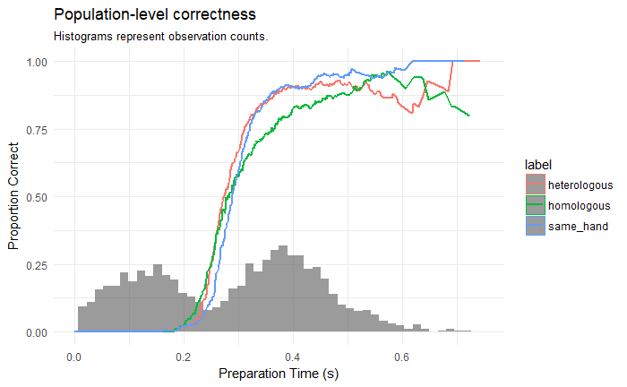

```r
dat[, 'slide_correct_group' := slider(real_prep_time, correct), by = c('label')]
dat[, 'slide_correct_id' := slider(real_prep_time, correct), by = c('label', 'id')]
ggplot(dat, aes(x = real_prep_time, y = slide_correct_group, colour = label)) +
  geom_histogram(data = dat, aes(x = real_prep_time, y = ..density../10, colour = NULL),
                 bins = 50, alpha = 0.6) +
  geom_line(size = 1) +
  xlim(c(0, 0.75)) +
  labs(x = 'Preparation Time (s)',
       y = 'Proportion Correct',
       title = 'Population-level correctness',
       subtitle = 'Histograms represent observation counts.')
```

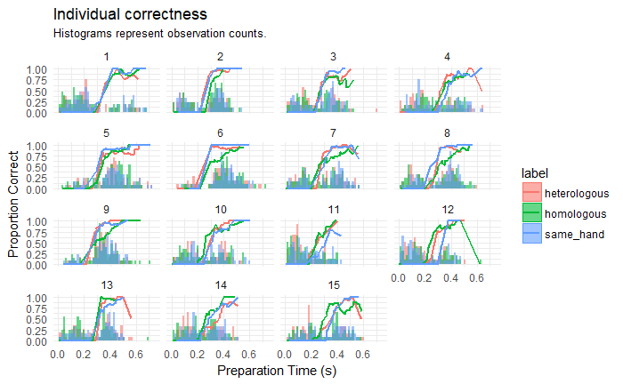

```r
ggplot(dat[block > 1], aes(x = real_prep_time, y = slide_correct_id, colour = label)) +
  geom_histogram(data = dat, aes(x = real_prep_time, y = ..density../10, colour = NULL, fill = label),
               bins = 50, alpha = 0.6, position = 'identity') +
  geom_line(size = 1) +
  xlim(c(0, 0.75)) +
  labs(x = 'Preparation Time (s)',
       y = 'Proportion Correct',
       title = 'Individual correctness',
       subtitle = 'Histograms represent observation counts.') +
  facet_wrap(~id)
```

In these first two figures, the x-axis is the amount of time the subject had to prepare, the y-axis is the (smoothed) proportion of the time they got the correct answer, and the color refers to the type of switch (homologous, heterologous, same hand). The histogram in the background represents the (relative) amount of data collected, and gives us an idea of how well we sampled across preparation times.

The second figure is the same, except each facet is performance of a single subject.

Coverage is pretty weak in our region of interest (~ 300ms), but one particularly interesting thing is that the homologous finger seems *slower* than the others (or more precisely, it takes longer to choose the correct action in that pair compared to the others).

Next, we can see the sorts of errors people were making when **not** going to the correct choice.

```r
# choice
dat[, 'chose_old' := first_image == first_press]
dat[, 'chose_new' := second_image == first_press]
dat[, 'chose_null' := chose_old == chose_new] # chose neither old nor new (one of the other choices)
dat[, 'hand_choice' := ifelse(first_press > 5, 'right', 'left')]
dat[, 'chose_null_old_hand' := chose_null & (hand_choice == first_hand)]
dat[, 'chose_null_new_hand' := chose_null & !chose_null_old_hand]
dat[, 'slide_old_group' := slider(real_prep_time, chose_old), by = c('label')]
dat[, 'slide_new_group' := slider(real_prep_time, chose_new), by = c('label')]
dat[, 'slide_null_group' := slider(real_prep_time, chose_null), by = c('label')]
dat[, 'slide_null_old_hand_group' := slider(real_prep_time, chose_null_old_hand), by = c('label')]
dat[, 'slide_null_new_hand_group' := slider(real_prep_time, chose_null_new_hand), by = c('label')]
dat[, 'slide_old_id' := slider(real_prep_time, chose_old), by = c('label', 'id')]
dat[, 'slide_new_id' := slider(real_prep_time, chose_new), by = c('label', 'id')]
dat[, 'slide_null_id' := slider(real_prep_time, chose_null), by = c('label', 'id')]
dat[, 'slide_null_old_hand_id' := slider(real_prep_time, chose_null_old_hand), by = c('label', 'id')]
dat[, 'slide_null_new_hand_id' := slider(real_prep_time, chose_null_new_hand), by = c('label', 'id')]
```

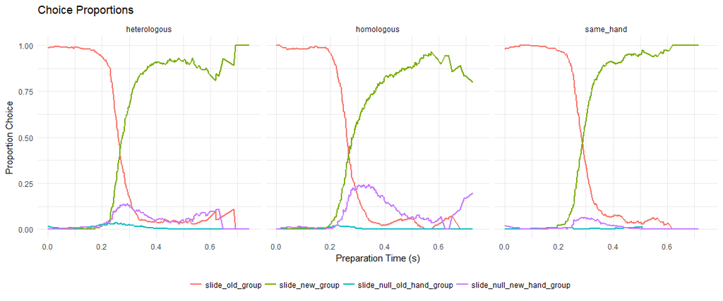

```r
# id, real_prep_time, slid_old_group, slide_new_group, slide_null_old_hand_group, slide_null_new_hand_group
tmp_dat <- dat[, c(4, 11, 19, 28:29, 31:32)]
tmp_dat <- melt(tmp_dat, id = c('id', 'label', 'real_prep_time'))
ggplot(tmp_dat, aes(x = real_prep_time, y = value, colour = variable)) +
  geom_line(size = 1) +
  xlim(c(0, 0.75)) +
  facet_wrap(~label) +
  labs(x = 'Preparation Time (s)',
       y = 'Proportion Choice',
       title = 'Choice Proportions') +
  theme(legend.position = "bottom") +
  guides(colour = guide_legend(title = NULL))
```

Here, the x-axis is the preparation time, the y-axis is the proportion of the time the subject made a particular choice, the colors represent those choices (more below), and the facets are for each switch type (homologous, heterologous, same hand).

This plot takes a bit of interpretation.

- `slide_old_group` is the proportion of the time they went to the original (now incorrect) response.
- `slide_new_group` is the proportion of the time they went to the new (now correct) response.
- `slide_null_old_hand_group` is the proportion of the time they did not go to either of the above, but went to a finger on the original hand. Example: fingers are [2 4 7 9]. Original was 2, switch was 7, but they went to 4.
- `slide_null_new_hand_group` is the proportion of the time that instead of going to the first three options, they went to a finger on the opposite hand. Example same as above, but instead went to 9.

Table for (hopefully more) clarity:

| Color | Heterologous | Homologous | same_hand |
| --- | --- | --- | --- |
| Red | old finger | old finger | old finger |
| Green | heterologous | homologous | same hand |
| Purple | homologous | heterologous | any on opposite hand |
| Cyan | same hand | same hand | (impossible) |

Here’s the same thing, overlaid the other way:

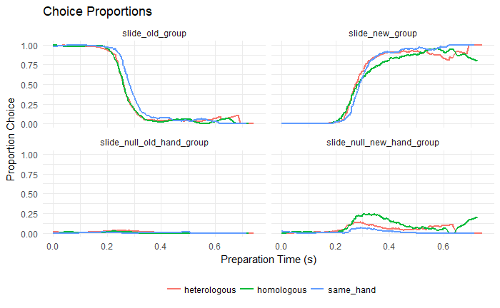

```r
ggplot(tmp_dat, aes(x = real_prep_time, y = value, colour = label)) +
  geom_line(size = 1) +
  xlim(c(0, 0.75)) +
  facet_wrap(~variable) +
  labs(x = 'Preparation Time (s)',
       y = 'Proportion Choice',
       title = 'Choice Proportions') +
  theme(legend.position = "bottom") +
  guides(colour = guide_legend(title = NULL))
```

The interesting thing is that for some reason, people have difficulty switching to the homologous finger on the opposite side (green curve, top right). They stop going to the old “incorrect” action at the same time as the other conditions (top left), and even begin choosing the correct action at comparable latency/accuracy compared to the other conditions (top right, pre-300 ms). From about 300-400ms, subjects are not as likely to select the homologous finger. Instead, they seem to select the heterologous finger on the opposite side. This likely isn’t solely related to issues with the stimuli (related to figuring out *which* finger to push), as then we would expect the heterologous and homologous choice rates to match (bottom right).

Thoughts:

```r
tmp_dat <- dat[, c(4, 11, 18, 32:33, 35:36)]
tmp_dat <- melt(tmp_dat, id = c('id', 'label', 'real_prep_time'))
```

[output not shown]

```
Error in melt.data.table(tmp_dat, id = c("id", "label", "real_prep_time")) :
  One or more values in 'id.vars' is invalid.
```

```r
dat[,choice := ifelse(chose_old, 1, ifelse(chose_new, 2, ifelse(chose_null_old_hand, 3, 4)))]
dat$label <- as.factor(dat$label)
# m1 <- brm(choice ~ s(real_prep_time,by = label) + (1|id),
#           family = categorical(),
#           data = dat,
#           chains = 3,
#           cores = 3,
#           iter = 2000)
```

TODO:

- Force traces/max